# Reaching Insights about Stuff: Getting A Broad Picture With Linear Modeling

The new era of Blaseball has come with a completely rewritten simulation with completely new attributes. Many of us in SIBR want to figure out what these attributes do! But it’s hard to know where to look first, or how to study them. And it’s tempting to want to figure out “the whole picture” for a given interaction or attribute. But I want to take a simpler approach. Rather than try to solve a question like “what does thwack do,” I want to get a broad sense of what attributes are *related to* various performance stats. To do this, let’s just use one of the simplest tools available to a statistician: [linear regression](https://en.wikipedia.org/wiki/Linear_regression).

I’m using R (through RStudio and the tidyverse ecosystem) for this post, because it’s designed for statistical analysis, it’s elegant at it, and I wanted to learn how to use it better. Plus it lets me write pretty reports like this using RMarkdown!

If you want to skip around, here are some heading links:

- Summary
- Data Loading & Cleaning
- Batting
- Pitching
- Fielding

## Data Loading & Cleaning

First, of course, we load the data. I’ve already done the work of joining the player stats from [Abyline’s Season N1 stats spreadsheet](https://docs.google.com/spreadsheets/d/18_FR5DaN3w4PrxawNHbUXgeBum6ia0X-PF5jHmIRAtY/edit#gid=394555595) to player attributes gathered from our `https://api2.sibr.dev/mirror/players` endpoint, and saved it as a CSV file. You can find a copy of this CSV file [here](https://faculty.sibr.dev/~glumbaron/player_stats_attrs_day90.csv).

```r
library(tidyverse)
library(janitor)
library(sjPlot)

players_stats <- read_csv("player_stats_attrs_day90.csv")

# Clean column names and calculate columns we'll want later
players_stats <- players_stats %>%
  clean_names() %>%
  select(-heatmap) %>%
  mutate(
    # batting: walk rate and strikeout rate
    bb_pa = bb / pa,
    k_pa = k / pa,
    # batting: rate of types of hit
    x1b_h = x1b / hit,
    x2b_h = x2b / hit,
    x3b_h = x3b / hit,
    hr_h = hr / hit,
    xbh_h = (x2b + x3b) / hit,
    # fielding: rate of hit types allowed per hits, or per BIP
    x1b_h_f= x1b_alwd / hits_alwd,
    x1b_bip_f= x1b_alwd / totl_fields,
    x2b_bip_f= x2b_alwd / totl_fields,
    x3b_bip_f= x3b_alwd / totl_fields,
    adv_fields = adv_alwd / totl_fields,
    # fielder Manhattan distances from bases
    home_dist = abs(posx - 0) + abs(posy - 0),
    first_dist = abs(posx - 2) + abs(posy - 0),
    second_dist = abs(posx - 2) + abs(posy - 2),
    third_dist = abs(posx - 0) + abs(posy - 2),
    fifth_dist = abs(posx - 0) + abs(posy - 4),
    zeroth_dist = abs(posx - 4) + abs(posy - 0),
  )
```

Now we have a data frame with attributes, batting stats, pitching stats, and fielding stats all together. It’s much too wide to display usefully here, sorry.

```r
head(players_stats)
```

```
## # A tibble: 6 × 102
##   id       name  team_…¹ locat…² locat…³ posit…⁴ modif…⁵ overa…⁶ batti…⁷ pitch…⁸
##   <chr>    <chr> <chr>   <chr>     <dbl> <chr>   <chr>     <dbl>   <dbl>   <dbl>
## 1 df94a33… Pang… Moab H… LINEUP        0 [(3, 2… <NA>       2.45    3.89    1.60
## 2 ceb5606… Lond… Moab H… ROTATI…       1 [(0, 2… <NA>       2.95    3.03    3.15
## 3 9ba361a… Moon… Moab H… ROTATI…       4 [(5, 0… <NA>       2.38    2.53    3.67
## 4 ff5a37d… Dunn… Moab H… ROTATI…       3 [(0, 5… <NA>       2.53    1.17    4.64
## 5 51dab86… Crav… Moab H… LINEUP        7 [(0, 1… <NA>       2.35    3.48    2.88
## 6 8c02857… Will… Moab H… LINEUP        8 [(4, 1… <NA>       1.99    3.97    2.12
## # … with 92 more variables: defense_rating <dbl>, running_rating <dbl>,
## #   vibes_rating <dbl>, sight <dbl>, thwack <dbl>, ferocity <dbl>,
## #   control <dbl>, stuff <dbl>, guile <dbl>, reach <dbl>, magnet <dbl>,
## #   reflex <dbl>, hustle <dbl>, stealth <dbl>, dodge <dbl>, thrive <dbl>,
## #   survive <dbl>, drama <dbl>, posx <dbl>, posy <dbl>, pa <dbl>, ab <dbl>,
## #   hit <dbl>, k <dbl>, bb <dbl>, x1b <dbl>, x2b <dbl>, x3b <dbl>, hr <dbl>,
## #   fc <dbl>, dp <dbl>, tp <dbl>, sac <dbl>, rbi <dbl>, ba <dbl>, obp <dbl>, …
```

## Batting

From here, we can look at whatever we want. Let’s start simple: what attributes of the batter are related to their batting average?

```r
s_ba <- summary(lm(ba ~ sight + thwack + ferocity + control + stuff + guile + dodge + hustle + stealth + reach + magnet + reflex + thrive + survive + drama, data = players_stats))
tab_model(s_ba, show.ci = FALSE, show.se = TRUE, digits=4, digits.p=2, p.style="scientific_stars")
```

ba

Predictors

Estimates

std. Error

p

(Intercept)

0.0167

0.0124

1.81e-01

sight

0.0387 ***

0.0068

**4.19e-08**

thwack

0.1064 ***

0.0069

**4.40e-36**

ferocity

0.1715 ***

0.0067

**1.56e-66**

control

-0.0158 *

0.0061

**1.07e-02**

stuff

-0.0045

0.0062

4.70e-01

guile

-0.0148 *

0.0057

**1.04e-02**

dodge

-0.0017

0.0060

7.74e-01

hustle

0.0088

0.0067

1.93e-01

stealth

0.0521 ***

0.0068

**8.04e-13**

reach

0.0063

0.0063

3.16e-01

magnet

0.0126 *

0.0061

**3.92e-02**

reflex

0.0055

0.0059

3.50e-01

thrive

-0.0017

0.0065

7.99e-01

survive

0.0060

0.0065

3.54e-01

drama

0.0082

0.0064

2.00e-01

Observations

224

R<sup>2</sup> / R<sup>2</sup> adjusted

0.854 / 0.843

- p<0.05 ** p<0.01 *** p<0.001

This looks over-fit to me, but there are several very strong dependencies. Let’s drop all but the most significant ones:

```r
s_ba <- summary(lm(ba ~ sight + thwack + ferocity + stealth, data = players_stats))
tab_model(s_ba, show.ci = FALSE, show.se = TRUE, digits=4, digits.p=2, p.style="scientific_stars")
```

ba

Predictors

Estimates

std. Error

p

(Intercept)

0.0225 **

0.0070

**1.40e-03**

sight

0.0369 ***

0.0069

**2.10e-07**

thwack

0.1065 ***

0.0070

**2.45e-36**

ferocity

0.1725 ***

0.0068

**1.50e-67**

stealth

0.0533 ***

0.0067

**1.05e-13**

Observations

224

R<sup>2</sup> / R<sup>2</sup> adjusted

0.838 / 0.835

- p<0.05 ** p<0.01 *** p<0.001

The fit quality is almost identical with just four factors, so I think we’re justified dropping the others. My conclusion: Batting average is positively correlated with **ferocity**, **thwack**, **stealth**, and **sight** (in roughly that order). Stealth’s presence here is weird; I expected hustle might matter just from the plain meaning of the word, but not stealth.

For the rest of this post I’ll skip to the “best” fit I have, but this is in general how I do these. I am not trying to make strong claims, so I am not worrying about whether my statistical practice is optimal. I’m also skipping showing the code; it all looks pretty much identical to the previous block, just with different variables, and different formatting arguments.

Onward to on-base percentage and slugging percentage:

obp

Predictors

Estimates

std. Error

p

(Intercept)

0.0785 ***

0.0072

**2.16e-22**

sight

0.0473 ***

0.0071

**2.44e-10**

thwack

0.0780 ***

0.0072

**3.93e-22**

ferocity

0.1644 ***

0.0070

**6.54e-62**

stealth

0.0508 ***

0.0069

**4.73e-12**

Observations

224

R<sup>2</sup> / R<sup>2</sup> adjusted

0.803 / 0.799

- p<0.05 ** p<0.01 *** p<0.001

slg

Predictors

Estimates

std. Error

p

(Intercept)

-0.0753 ***

0.0170

**1.53e-05**

sight

0.0853 ***

0.0168

**8.74e-07**

thwack

0.2156 ***

0.0171

**7.35e-28**

ferocity

0.3801 ***

0.0165

**2.44e-60**

stealth

0.2203 ***

0.0164

**2.34e-30**

Observations

224

R<sup>2</sup> / R<sup>2</sup> adjusted

0.825 / 0.822

- p<0.05 ** p<0.01 *** p<0.001

Wow, it’s the same four attributes! For OBP, it’s **ferocity**, **thwack**, **stealth**, and **sight** (sight is a bit stronger here than for BA). For SLG, it’s **ferocity**, **stealth**, **thwack**, and **sight**, with ferocity being almost twice as strong as stealth and thwack, which are on par with each other. Interesting. Let’s do walk rate and strikeout rate next:

bb/pa

Predictors

Estimates

std. Error

p

(Intercept)

0.0592 ***

0.0026

**1.39e-58**

sight

0.0159 ***

0.0033

**2.54e-06**

thwack

-0.0297 ***

0.0033

**1.44e-16**

Observations

224

R<sup>2</sup> / R<sup>2</sup> adjusted

0.305 / 0.298

- p<0.05 ** p<0.01 *** p<0.001

k/pa

Predictors

Estimates

std. Error

p

(Intercept)

0.3534 ***

0.0055

**6.59e-145**

sight

-0.0863 ***

0.0068

**8.26e-28**

thwack

-0.2095 ***

0.0069

**7.78e-81**

Observations

224

R<sup>2</sup> / R<sup>2</sup> adjusted

0.840 / 0.838

- p<0.05 ** p<0.01 *** p<0.001

They’re both just **sight** and **thwack**! Perhaps sight helps you draw walks and avoid strikeouts, while thwack makes both less likely. My guess is that higher thwack batters put the ball into play more, which would make both these outcomes less frequent. Important note, though: The R<sup>2</sup> for BB/PA is *much lower* than the other fits we’ve done so far, which suggests that most of the variation is not being captured by our variables. Which makes sense; I’m not considering pitcher attributes at all (I can’t, with this dependent variable).

So what’s up with stealth from earlier? Stealth is important for “power”? That’s weird. Let’s look at the rates of types of hit relative to total hits, so HR/H, 3B/H, etc:

hr/h

Predictors

Estimates

std. Error

p

(Intercept)

0.0611 ***

0.0092

**2.09e-10**

ferocity

0.1156 ***

0.0115

**9.23e-20**

survive

-0.0369 ***

0.0110

**9.53e-04**

Observations

224

R<sup>2</sup> / R<sup>2</sup> adjusted

0.335 / 0.329

- p<0.05 ** p<0.01 *** p<0.001

3b/h

Predictors

Estimates

std. Error

p

(Intercept)

0.0044

0.0040

2.71e-01

stealth

0.1049 ***

0.0075

**3.12e-32**

Observations

224

R<sup>2</sup> / R<sup>2</sup> adjusted

0.468 / 0.465

- p<0.05 ** p<0.01 *** p<0.001

2b/h

Predictors

Estimates

std. Error

p

(Intercept)

0.1719 ***

0.0088

**7.81e-50**

stealth

0.4005 ***

0.0165

**1.41e-64**

Observations

224

R<sup>2</sup> / R<sup>2</sup> adjusted

0.727 / 0.726

- p<0.05 ** p<0.01 *** p<0.001

1b_h

Predictors

Estimates

std. Error

p

(Intercept)

0.7568 ***

0.0138

**1.69e-130**

ferocity

-0.0905 ***

0.0175

**5.31e-07**

stealth

-0.4840 ***

0.0175

**8.21e-74**

Observations

224

R<sup>2</sup> / R<sup>2</sup> adjusted

0.782 / 0.780

- p<0.05 ** p<0.01 *** p<0.001

I’ve cut down variables pretty aggressively here. The R<sup>2</sup> values aren’t all that high for some of these, no matter how many batter attributes I include. Clearly, it’s not just up to the batter—the pitcher and defense should matter for these! The best I’ve got is the observation that **ferocity** increases home run rate, **stealth** increases double and triple rate, and both of those, in turn, decrease single rate the same amount that they increase the other outcomes. There is also my first trace of a vibes attribute, as **survive** seems to be showing up in the home run rate. It’s a negative factor, though, which I don’t understand. I have no current model for how vibes might work, though, so I’m just glad to see one of the vibes attributes stick around in anything, even if it’s barely below the 0.001 significance threshold for the weakest fit in this set. As another friend put it, “someone in the data set hits home runs, and we think they might have less survive, but we’re not sure” is probably the most you can conclude from that relationship.

## Pitching

Now let’s move on to pitching stats! First, perhaps the most general pitching stat, ERA:

era

Predictors

Estimates

std. Error

p

(Intercept)

6.4636 ***

0.2177

**9.27e-56**

control

-1.6023 ***

0.2322

**3.00e-10**

stuff

-2.3187 ***

0.2174

**6.99e-19**

guile

-1.3332 ***

0.2373

**1.37e-07**

Observations

119

R<sup>2</sup> / R<sup>2</sup> adjusted

0.657 / 0.648

- p<0.05 ** p<0.01 *** p<0.001

ERA has a strong relationship with all 3 pitching attributes. In order of importance, **stuff** > **control** > **guile**, though it’s fairly balanced. The R<sup>2</sup> of 0.65 suggests that there is a lot more going on than just this, which is good, because of course there is.

Now, let’s look at rate stats for outcomes. Strikeouts per 9 innings:

so 9

Predictors

Estimates

std. Error

p

(Intercept)

1.5499 ***

0.2293

**6.03e-10**

control

1.6609 ***

0.2446

**5.18e-10**

stuff

4.8418 ***

0.2290

**1.99e-41**

guile

2.5841 ***

0.2500

**4.13e-18**

Observations

119

R<sup>2</sup> / R<sup>2</sup> adjusted

0.857 / 0.853

- p<0.05 ** p<0.01 *** p<0.001

Strikeouts seem to be **stuff** > **guile** > **control**. Plausibly, “better stuff” is harder to hit, and “trickier pitches” are as well. To look deeper at this, if I had a per-pitch data set I would want to investigate swinging strikes with a logistic regression.

Now, walks per 9 innings:

bb 9

Predictors

Estimates

std. Error

p

(Intercept)

4.5057 ***

0.2168

**9.51e-41**

control

-5.0199 ***

0.2313

**1.76e-42**

stuff

0.5268 *

0.2165

**1.65e-02**

guile

-0.3886

0.2363

1.03e-01

Observations

119

R<sup>2</sup> / R<sup>2</sup> adjusted

0.812 / 0.808

- p<0.05 ** p<0.01 *** p<0.001

You heard it here, folks; stuff increases walks. Seriously though, it’s really just **control**. If you can throw strikes, you won’t walk people. Remarkable! If you plot the relationship, it’s quite clear, and also not actually linear (I should do another post that just has a bunch of plots, honestly).

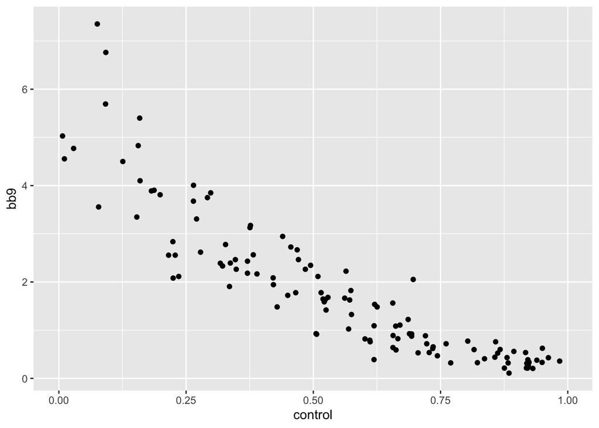

Scatter plot of BB/9 versus Control. Walk rate appears to be inversely related to Control, in some fashion.

Let’s look at hits per 9 innings next:

h 9

Predictors

Estimates

std. Error

p

(Intercept)

11.0716 ***

0.3107

**2.52e-64**

stuff

-3.3510 ***

0.3629

**1.48e-15**

guile

-2.0845 ***

0.3934

**5.62e-07**

Observations

119

R<sup>2</sup> / R<sup>2</sup> adjusted

0.527 / 0.519

- p<0.05 ** p<0.01 *** p<0.001

Hits depend on **stuff** and **guile**, it seems. We’re barely above 0.5 R<sup>2</sup>, though, so clearly the pitcher is not the only determinant of this; the batter and defense factors will matter a lot too.

Now, how about home runs per 9? Those probably don’t depend on the defense.

hr 9

Predictors

Estimates

std. Error

p

(Intercept)

1.4010 ***

0.0601

**1.45e-45**

stuff

-0.5736 ***

0.0702

**4.39e-13**

guile

-0.2750 ***

0.0761

**4.50e-04**

Observations

119

R<sup>2</sup> / R<sup>2</sup> adjusted

0.436 / 0.426

- p<0.05 ** p<0.01 *** p<0.001

Home run rate also depends on **stuff** and **guile**, but less strongly: only about 0.425 R<sup>2</sup>. I could be glib and say that 40% of home runs is the pitcher, 40% is the batter, and 20% is, I don’t know, the pitcher and batter heatmaps. But I won’t say that. You can’t pin that on me!

Last fit for this section: batting average on balls in play (BABIP). In the Beta-era simulation, pitchers had a pretty significant impact on this, through Unthwackability. Do we still see that sort of impact in the new simulation?

babip

Predictors

Estimates

std. Error

p

(Intercept)

0.3301 ***

0.0103

**3.46e-59**

control

0.0043

0.0110

6.96e-01

stuff

-0.0410 ***

0.0103

**1.19e-04**

guile

-0.0307 **

0.0112

**7.22e-03**

Observations

119

R<sup>2</sup> / R<sup>2</sup> adjusted

0.190 / 0.169

- p<0.05 ** p<0.01 *** p<0.001

This fit is quite rough. **Stuff** has the strongest relationship to BABIP of the three pitching attributes, but…just look at it. It’s not strong. But maybe it’s not nothing? It’s definitely nowhere near as strong as Unthwackability used to be, though.

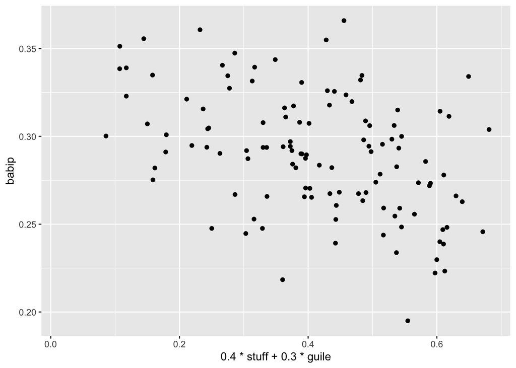

Scatter plot of BABIP versus a linear combination of Stuff and Guile. The relationship seems very weak; there is a possible hint of a negative slope, but tons of scatter.

## Fielding

The fielding stats that we have in this data set aren’t very sophisticated, so we can only do so much with them. But we can at least get a start, here. Besides, it’s much harder to interpret a complicated derived stat regressed against attributes, because there is so much more going on. Let’s start with a super basic one: how many plays will a fielder actually get?

totl fields

Predictors

Estimates

std. Error

p

(Intercept)

108.6787 ***

17.2095

**1.47e-09**

reach

302.2577 ***

19.3756

**1.92e-37**

magnet

8.6891

18.8928

6.46e-01

reflex

11.5943

18.1542

5.24e-01

Observations

224

R<sup>2</sup> / R<sup>2</sup> adjusted

0.527 / 0.521

- p<0.05 ** p<0.01 *** p<0.001

It seems that total balls fielded only depends on **reach**. And this is obviously quite incomplete; R<sup>2</sup> of 0.5 is Not So Great.

The next natural question to ask is, what about the fielder’s rate of getting outs from balls in play (i.e, `outs/plays)`?

outs/plays

Predictors

Estimates

std. Error

p

(Intercept)

0.6437 ***

0.0045

**1.12e-219**

magnet

0.1921 ***

0.0077

**1.52e-66**

Observations

224

R<sup>2</sup> / R<sup>2</sup> adjusted

0.738 / 0.737

- p<0.05 ** p<0.01 *** p<0.001

This seems to just be related to **magnet**. This at least has more explanatory power than reach did above (I guess, if you’re willing to interpret R<sup>2</sup> that way, which is probably wrong in some way that I can’t explain properly?).

Beyond this, the stats I have here stop being very amenable to this kind of analysis. The problem is, they’re mostly all the same. The more reach you have, the more plays you’re involved in, so the more outs you get, but also the more “hits you give up”, the more “runs you allow”, etc. Having more magnet seems to increase the “good” defensive outcomes and decrease the “bad” ones. None of that adds any insight.

But there is one more thing I want to try. Let’s get bold and look at double plays started for each fielder. Thanks to my buddy Nate (GraveError on discord), who saw these trends when looking at high-double-play fielders and suggested them to me.

double plays

Predictors

Estimates

std. Error

p

(Intercept)

8.3421 ***

1.0772

**3.44e-13**

reflex

6.1571 ***

1.2423

**1.43e-06**

first dist

-1.9730 ***

0.1893

**5.94e-21**

Observations

224

R<sup>2</sup> / R<sup>2</sup> adjusted

0.383 / 0.378

- p<0.05 ** p<0.01 *** p<0.001

By the way, I didn’t find even a hint of a relationship between batter attributes and *grounding into* double plays. It’s probably mostly on the defense, I guess?

Let’s finish up by looking at runner advances allowed, divided by balls fielded:

advances/fields

Predictors

Estimates

std. Error

p

(Intercept)

0.0714 ***

0.0041

**9.35e-44**

reflex

-0.0500 ***

0.0068

**3.27e-12**

home dist

-0.0065 ***

0.0007

**6.15e-17**

reflex × home dist

0.0060 ***

0.0012

**1.03e-06**

Observations

224

R<sup>2</sup> / R<sup>2</sup> adjusted

0.397 / 0.389

- p<0.05 ** p<0.01 *** p<0.001